# R5.01 - Environnement économique : Économie des inégalités

Chapitre 1: Introduction générale du cours

Thomas Delcey

thomas.delcey@ube.fr

Université de Bourgogne Europe

# Introduction générale du cours

### Environnement économique

**Définition : l’environnement économique**

L’environnement économique désigne l’ensemble des facteurs économiques qui influencent le fonctionnement, la performance et la prise de décision des acteurs économiques (croissance, inflation, taux d’intérêt, chômage, inégalités, etc.).

**Objectif du cours**

L’objectif du cours est de vous donner les bases nécessaires pour comprendre les inégalités économiques, leurs causes et leurs conséquences, ainsi que les politiques publiques visant à les réduire.

### Rappel sur l’économie

- L’économie est une:
  1. science
  2. sociale
  3. descriptive
  4. normative

[figure not shown]

Louis XV, souverain de la France en 1750. Peinture de Louis-Michel van Loo (1762).

**Expérience de pensée**

- Vous naissez en 1750. Vous êtes immortel et vous gagnez 10 000 € par jour.
- En supposant que vous n’avez jamais dépensé un seul de ces **10 000 €** par jour depuis 1750, combien aurez-vous aujourd’hui ?
- En 2026, vous avez accumulé 1,01 milliard d’euros.
- Pour atteindre **100 milliards** sur la même période, il aurait fallu gagner 992 000 € **par jour**, sans jamais rien dépenser.

Ce calcul est une illustration des ordres de grandeur, pas des mécanismes d’enrichissement : il n’y ni inflation, ni rendements composés.

Les **0,001 %** les plus riches — environ **56 000 adultes** — détiennent 3 fois le patrimoine des **50 %** les plus pauvres de la planète. Source: Chancel et al. (2025).

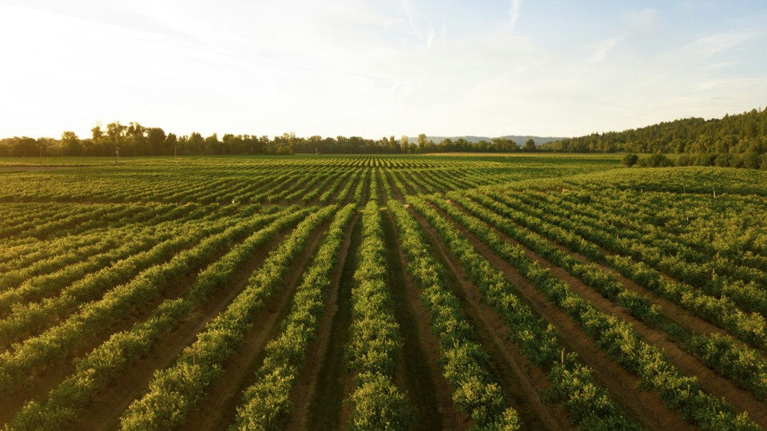

**Combien de calories produit-on par jour et par personne ?**

- Nous produisons en moyenne **5 935 kcal** par personne et par jour de cultures directement comestibles (Berners-Lee et al. 2018).
- C’est plus que deux fois les besoins quotidiens.
- En **2023**, **9,2 %** de la population mondiale (**735 millions**) souffre de faim chronique.
- **29,6 %** (**2,4 milliards**) souffre d’insécurité alimentaire.

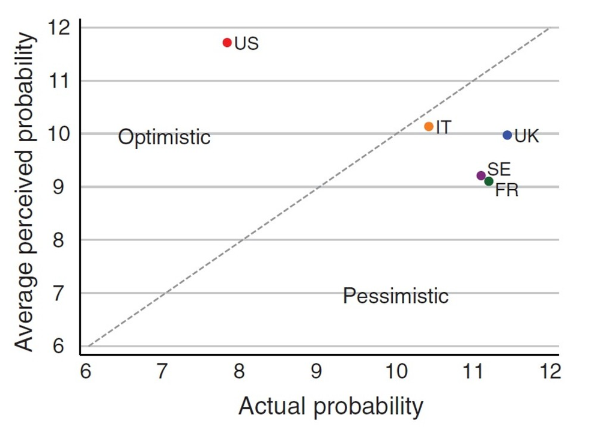

Figure issue de Alesina, Stantcheva, et Teso (2018). Intergenerational mobility and preferences for redistribution. *American Economic Review*, 108(2), 521-554.

- Cinq pays comparés en **2018** : États-Unis, France, Italie, Royaume-Uni, Suède (Alesina, Stantcheva, et Teso 2018).
- Mobilité mesurée en **5** quintiles de **20 %** chacun.
- Chaque point compare la probabilité **réelle** qu’un enfant du quintile le plus pauvre atteigne le plus riche (abscisse) et la probabilité **perçue** par les habitants du pays (ordonnée).
- Être sur la diagonale, c’est voir juste.
- **Les États-Unis sont le seul pays au-dessus** : la mobilité réelle y est la plus faible des cinq (**8 %**), et c’est là qu’on la surestime le plus (**12 %** perçus).
- **La France est à l’opposé** : la mobilité réelle (**11 %**) est sous-estimée (**9 %** perçus).

### Facteurs de production et leurs rémunérations

**Définition : facteurs de production**

Les facteurs de production sont les ressources utilisées dans le processus de production de biens et services. Ils sont généralement classés en deux catégories principales: le capital (K) et le travail (L).

- $Y = \sum_{i=1}^{n} VA_i$
- $Y = F(K, L)$
- $Y = pK + wL = P + W$

**Pourquoi $P$ existe-t-il ?**

### La critique des propriétaires du capital

> « Vous êtes saisis d’horreur parce que nous voulons abolir la propriété privée. Mais, dans votre société, la propriété privée est abolie pour les neuf dixièmes de ses membres. […] Le communisme n’enlève à personne le pouvoir de s’approprier des produits sociaux; il n’ôte que le pouvoir d’asservir à l’aide de cette appropriation le travail d’autrui. »

Marx et Engel dans *Le manifeste du parti communiste* (1848)

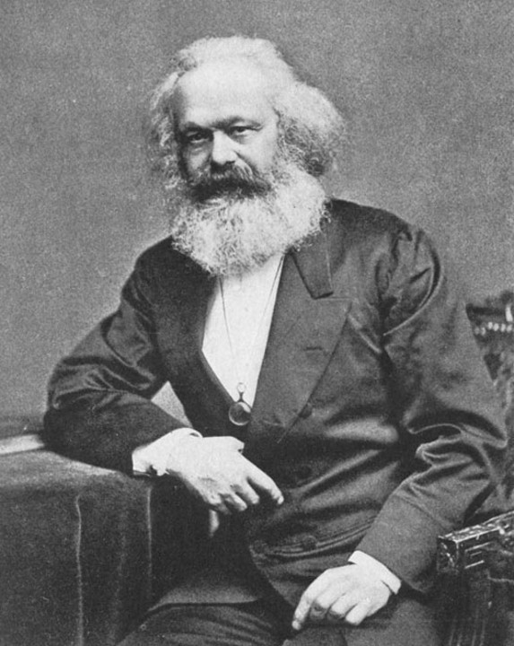

### La défense des propriétaires du capital

> « [Marx] n’avait pas de théorie de l’entreprise et son incapacité à distinguer l’entrepreneur du capitaliste […] explique de nombreux cas de *non sequitur* et de nombreuses erreurs. »

> « Ce processus de destruction créatrice est le fait essentiel du capitalisme.»

Joseph Schumpeter dans *Capitalisme, socialisme et démocratie* (1942)

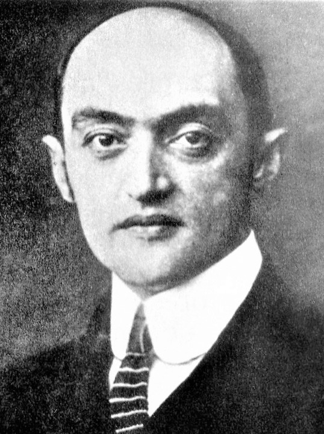

### La courbe de Kuznets

**Définition : la courbe de Kuznets**

- La courbe de Kuznets est une hypothèse économique formulée par l’économiste américain Simon Kuznets dans les années 1950.
- Elle suggère qu’il existe une relation en forme de U inversé entre le niveau de développement économique d’un pays et son niveau d’inégalités de revenus.

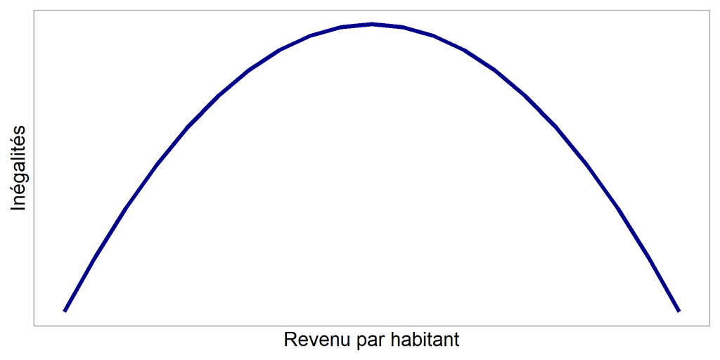

Figure 1: D’après Kuznets, Simon. (1955). « Economic Growth and Income Inequality ». The American Economic Review 45 (1): 1‑28.

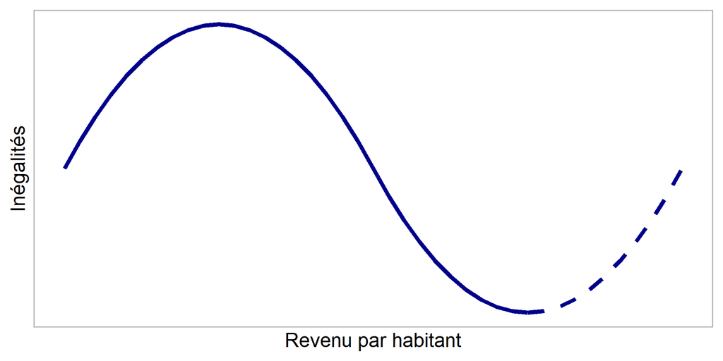

Figure 2: Actualisée

### Plan du cours

**Un chapitre, un problème:**

- Pourquoi (et faut-il) réduire les inégalités ?
- Définir une inégalité ;
- Mesurer les inégalités ;
- L’état des inégalités dans le monde et en France ;
- Les causes des inégalités: le salaire ;
- Les causes des inégalités: le capital ;
- Les politiques publiques de réduction des inégalités ;

### Évaluation

- Un QCM (40%): en TD, le 22 ou 23 septembre 2026
- Un examen final (60%): en TD: le 18 novembre 2026

### Références

Alesina, Alberto, Stefanie Stantcheva, et Edoardo Teso. 2018. « Intergenerational Mobility and Preferences for Redistribution ». *American Economic Review* 108 (2): 521‑54. https://doi.org/10.1257/aer.20162015.

Berners-Lee, M., C. Kennelly, R. Watson, et C. N. Hewitt. 2018. « Current global food production is sufficient to meet human nutritional needs in 2050 provided there is radical societal adaptation ». *Elementa: Science of the Anthropocene* 6 (1): 52. https://doi.org/10.1525/elementa.310.

Chancel, Lucas, Ricardo Gómez-Carrera, Rowaida Moshrif, et Thomas Piketty. 2025. « Rapport sur les inégalités mondiales 2026. Synthèse ». World Inequality Lab; https://wir2026.wid.world.

Kuznets, Simon. 1955. « Economic Growth and Income Inequality ». *The American Economic Review* 45 (1): 1‑28.

Marx, Karl, et Friedrich Engels. 1848. *The Communist Manifesto*.

Schumpeter, Joseph A. 1942. *Capitalism, Socialism and Democracy*.